# World’s Hardest Boulder Problems Sent by Women (V13 and Up)

**Table of Contents:**  
The World’s Hardest Boulder Problems Sent by Women  
V15 Club  
Who Is the Strongest Female Boulderer Ever?  
Trends Over Time  
How Many Women Can Climb V13 or Higher?  
Which Countries Have the Hardest Boulder Problems for Women?  
What About Age?  
Height?

**Last updated:** January 2022. If you notice anything that is an error, or you would like to help improve the list, please let me know.

[Note: this site and list are still under construction. Things I still need to do:  
- Fix table of contents  
- Add ability for users to comment]

The most climbed **V13** boulder is **Fragile Steps** with 17 ascents; followed by **Nuthin but Sunshine** and **Automator, The** with 7 and 6 ascents, respectively.

The most climbed **V14** boulder is **New Base Line** with 6 ascents; followed by **Jade** and **Catharsis** with 4 and 2 ascents, respectively.

[Here is a link](https://bit.ly/3FYSddM) to the Google Spreadsheet

# The World’s Hardest Boulder Problems Sent by Women

| Route Name | Climber | Consensus VGrade | FA | Country | Area | Date | Suggested VGrade by Climber |
| --- | --- | --- | --- | --- | --- | --- | --- |
| Agamemnon | Oriane Bertone | 13 |  | South Africa | Rocklands | 2020-01-16 | 13 |
| Alley, The | Alex Puccio | 13 |  | United States | RMNP | 2020-08-01 | 13 |
| Amandla | Isabelle Faus | 14 |  | South Africa | Rocklands | 2015-08-21 | 14 |
| Amber | Alex Puccio | 13 |  | Switzerland | Ticino | 2019-03-26 | 13 |
| Arch, The | Alizee Dufraisse | 13 |  | South Africa | Rocklands | 2018-08-06 | 13 |
| Arch, The | Irina Kuzmenko | 13 |  | South Africa | Rocklands | 2021-07-17 | 13 |
| Arch, The | Oriane Bertone | 13 |  | South Africa | Rocklands | 2019-01-10 | 13 |
| Arch, The | Staša Gejo | 13 |  | South Africa | Rocklands | 2021-07-05 | 13 |
| Armstrong assis | Matilda Soderlund | 13 |  | Sweden | Nockeby | 2020-04-25 |  |
| Army of the Dead | Allison Vest | 13 |  | United States | Joe's Valley | 2021-12-08 | 13 |

[output cut: 250 more lines]

# V15 Club

Currently it seems as though four women have climbed a V15 boulder: Ashima Shirashi with two (!) - Sleepy Rave and Horizon; Kaddi Lehman with Kriptos; Mishka Ishi with Byaku-dou; and Oriane Bertone with Satan i helvete bas.

# Who Is the Strongest Female Boulderer Ever?

The following are two bar plots based on the data in the above list showing who has sent the most hard boulder problems and who has put up the most hard boulder first ascents (FAs).

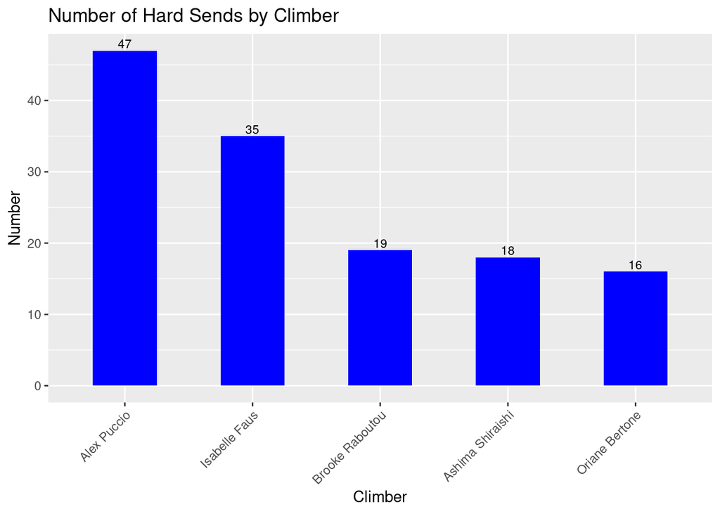

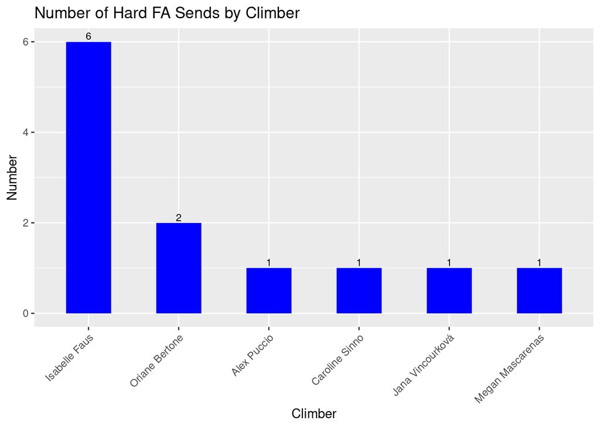

The strongest climber by most hard boulder sends is Alex Puccio with 47 ascents; 12 more than the Isabelle Faus with the second most ascents. However, Isabelle Faus has the most FAs with 6; 4 more than Oriane Bertone, and an impressive amount of hard sends to her name. Finally, as stated above, Ashima Shirashi has climbed two V15s, along with Kaddi Lehman, Mishka Ishi, and Oriane Bertone who have climbed one each - something that neither Alex Puccio nor Isabelle Faus has done.

# Trends Over Time

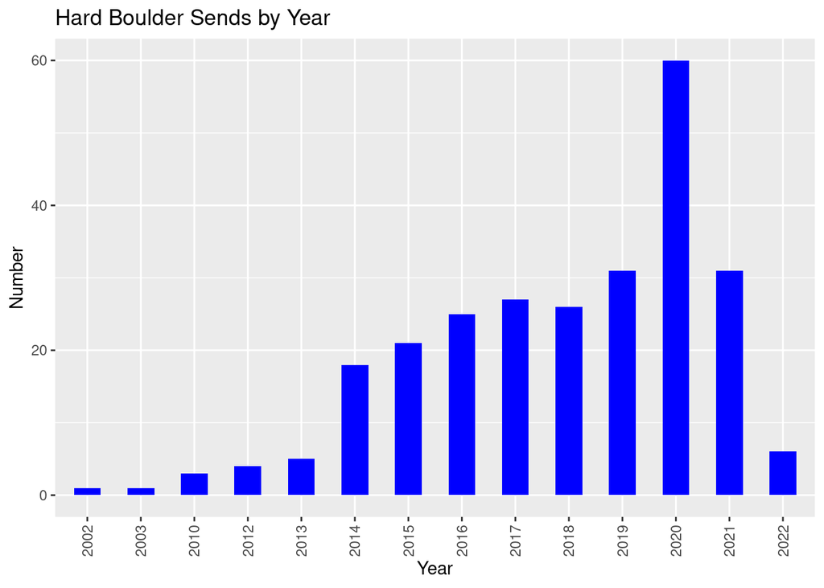

# How Many Women Can Climb V13 or Higher?

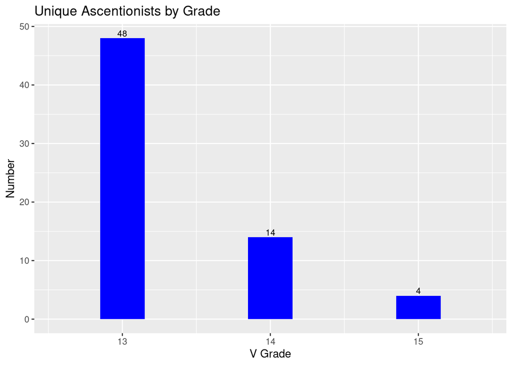

At the moment, there are 48 women in the world that have sent V13. After which there is a steep drop off, with 14 having sent V14, and 4 having sent V15.

# Which Countries Have the Hardest Boulder Problems for Women?

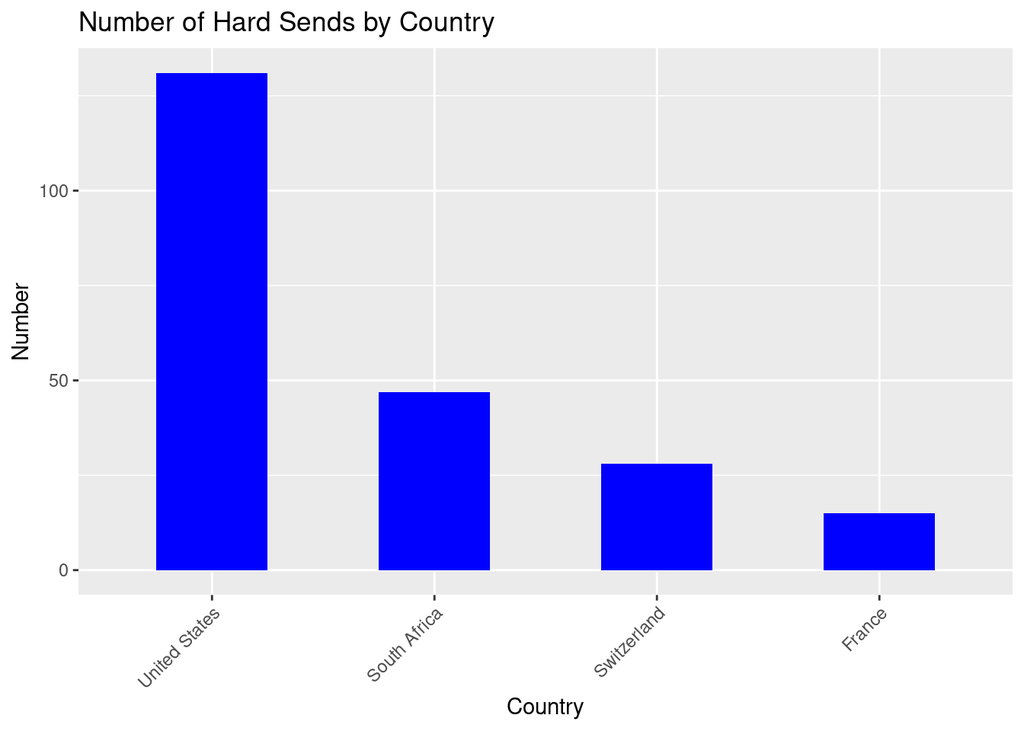

The Top Countries with the hardest female sends are the United States, South Africa, Switzerland, and France.

# What About Age?

What is the age of strong female climbers today?

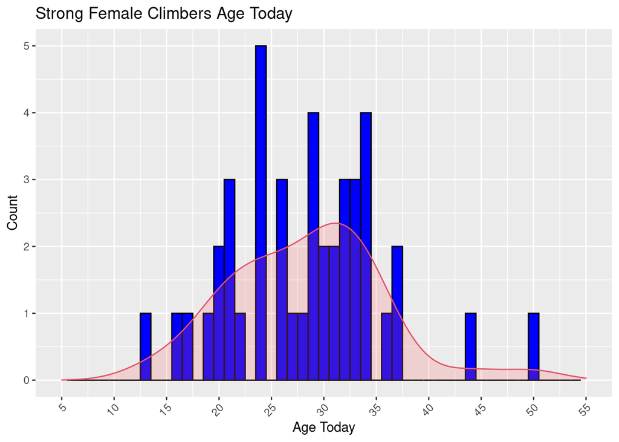

The mean, median and mode age of strong female climbers today is 28, 29, and 24, respectively.

The youngest V13 female climber today is 13 years old. The oldest V13 female climber today is 50 years old.

## What about stats on how old they are when they send the route?

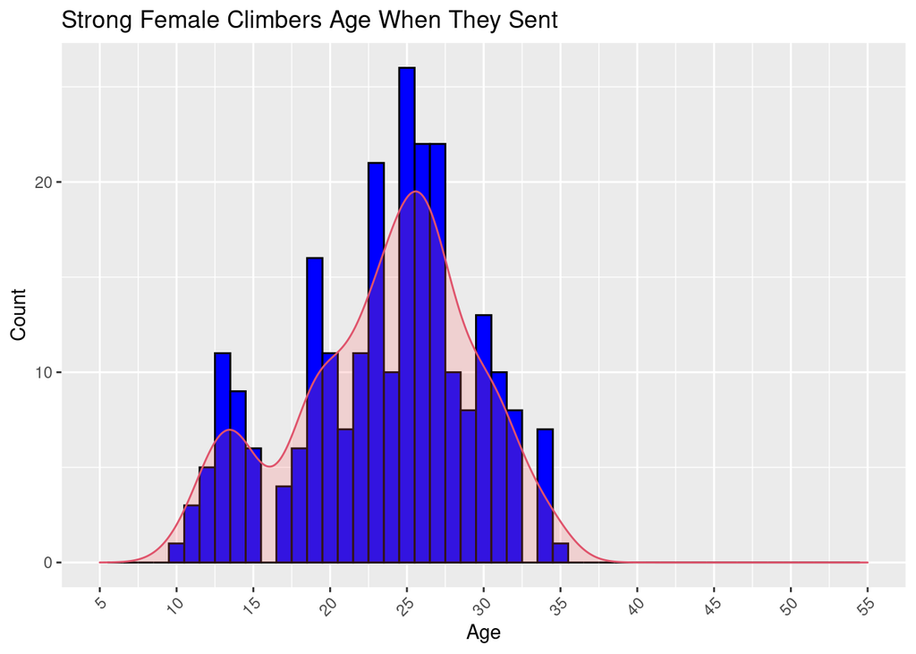

The mean, median and mode age of strong female climbers when they sent is 24, 25, and 25, respectively.

The youngest age to have climbed V13 or higher is 10 years old. The oldest age to have climbed V13 or higher is 35 years old.

# Climber’s Height

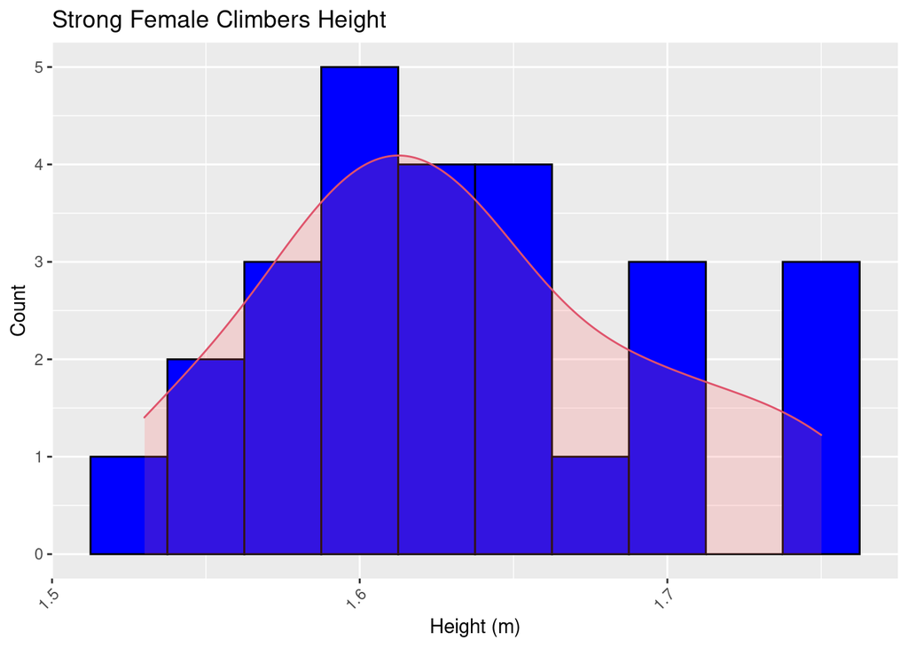

The mean, median and mode height of strong female climbers is 1.63, 1.62, and 1.6, respectively.

The shortest height to have climbed V13 or higher is 1.53 meters. The tallest height to have climbed V13 or higher is 1.75 meters.

*However, not all athlete’s record their bouldering ascents in 8a.nu. Another great resource was https://onbouldering.com/8b-senders-ladies-club/.*

*Finally, I then tried to standardize all entries, remove errors, and add in send dates. Ultimately this is still a work in progress, and if you see any errors, please reach out.*

*Special shout-out to Andrew Leyland for extensive help in filling out the spreadsheet.*